# Analysis

## NFL Gambling Market Analysis

### Objective:

- Investigate the existence of inefficiencies in the NFL gambling markets by building predictive models for point spread and over/under outcomes using historical game data.

### Data Preparation:

1. Load the Dataset
2. Check for Missing Values
3. Convert Schedule Week Values
4. Standardize Team Abbreviations

```python
import pandas as pd

# Load the dataset to inspect its structure and identify relevant columns
file_path = 'Dataset.xlsx'
nfl_data = pd.read_excel(file_path)

# Display basic information about the dataset
nfl_data_info = nfl_data.info()
nfl_data_head = nfl_data.head()

nfl_data_info, nfl_data_head
```

```
<class 'pandas.core.frame.DataFrame'>
RangeIndex: 11067 entries, 0 to 11066
Data columns (total 30 columns):
 #   Column                 Non-Null Count  Dtype
---  ------                 --------------  -----
 0   Schedule Date          11067 non-null  datetime64[ns]
 1   Start Time             11067 non-null  datetime64[ns]
 2   schedule_season        11067 non-null  int64
 3   Schedule Week          11067 non-null  object
 4   Schedule Playoff       11067 non-null  bool
 5   Team Home              11067 non-null  object
 6   Score Home             11067 non-null  int64
 7   Score Away             11067 non-null  int64
 8   Team Away              11067 non-null  object
 9   Team Favorite Id       11067 non-null  object
```

[output cut: 22 more lines]

```
(None,
   Schedule Date          Start Time  schedule_season Schedule Week  \
 0    1980-09-07 1980-09-07 13:00:00             1980             1
 1    1980-09-07 1980-09-07 13:00:00             1980             1
 2    1980-09-07 1980-09-07 13:00:00             1980             1
 3    1980-09-07 1980-09-07 13:00:00             1980             1
 4    1980-09-07 1980-09-07 13:00:00             1980             1

    Schedule Playoff           Team Home  Score Home  Score Away  \
 0             False       Buffalo Bills          17           7
 1             False  Cincinnati Bengals          12          17
 2             False   Green Bay Packers          12           6
 3             False  Kansas City Chiefs          14          27
 4             False    Los Angeles Rams          20          41

```

[output cut: 29 more lines]

### Week Conversion: Convert specific week string labels to integer values:

- **"Wildcard"** to 19
- **"Division"** to 20
- **"Conference"** to 21
- **"Superbowl"** to 22

**Team Coding Consistency:** Ensure that each team has a unique code for both home and away appearances.

```python
# Step 1: Convert specific week string labels to integers
# Define a mapping for week names to integers
week_mapping = {
    "Wildcard": 19,
    "Division": 20,
    "Conference": 21,
    "Superbowl": 22
}

# Apply the mapping to the 'Schedule Week' column where applicable
nfl_data['Schedule Week'] = nfl_data['Schedule Week'].replace(week_mapping).astype(int)

# Step 2: Team coding consistency
# Create a dictionary for unique team codes across home and away columns
team_codes = {}
team_counter = 1

# Function to assign or retrieve a code for a team
def get_team_code(team_name):
    global team_counter
    if team_name not in team_codes:
        team_codes[team_name] = team_counter
        team_counter += 1
    return team_codes[team_name]

# Apply consistent team codes to both 'Team Home' and 'Team Away' columns
nfl_data['Team Home Code'] = nfl_data['Team Home'].apply(get_team_code)
nfl_data['Team Away Code'] = nfl_data['Team Away'].apply(get_team_code)

# Display the modified dataset's head to review transformations
nfl_data[['Schedule Week', 'Team Home', 'Team Home Code', 'Team Away', 'Team Away Code']].head()
```

|  | Schedule Week | Team Home | Team Home Code | Team Away | Team Away Code |
| --- | --- | --- | --- | --- | --- |
| 0 | 1 | Buffalo Bills | 1 | Miami Dolphins | 19 |
| 1 | 1 | Cincinnati Bengals | 2 | Tampa Bay Buccaneers | 15 |
| 2 | 1 | Green Bay Packers | 3 | Chicago Bears | 17 |
| 3 | 1 | Kansas City Chiefs | 4 | Oakland Raiders | 28 |
| 4 | 1 | Los Angeles Rams | 5 | Detroit Lions | 26 |

### Analyze the distributions of the point spread and the total points scored in NFL games relative to the betting lines (over/under)

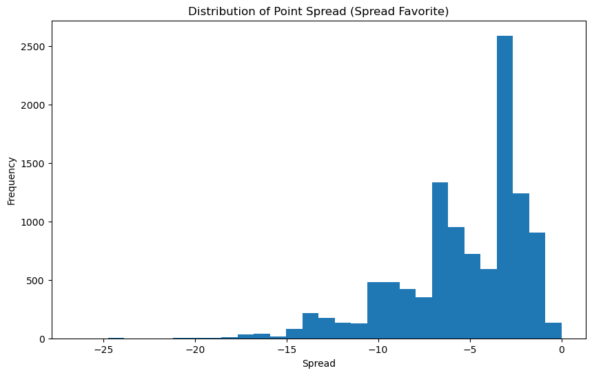

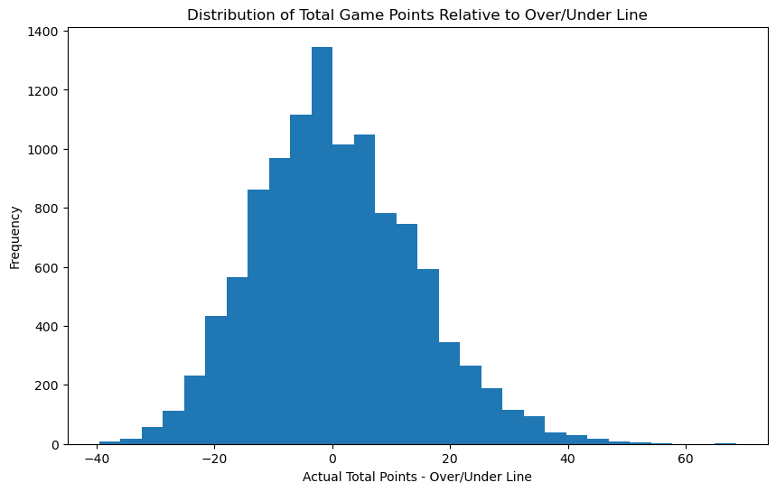

```
(count    11067.000000
 mean        -5.377609
 std          3.441896
 min        -26.500000
 25%         -7.000000
 50%         -4.500000
 75%         -3.000000
 max          0.000000
 Name: Spread Favorite, dtype: float64,
 count    11013.00000
 mean         0.58411
 std         13.61151
 min        -39.50000
 25%         -9.00000
 50%         -0.50000
 75%          9.00000
 max         68.50000
 dtype: float64)
```

```python
import matplotlib.pyplot as plt

# Calculate the actual game total points
nfl_data['Game Total Points'] = nfl_data['Score Home'] + nfl_data['Score Away']

# Convert Over Under Line to numeric, handling cases like 'PK' or other non-numeric entries by coercing them to NaN
nfl_data['Over Under Line'] = pd.to_numeric(nfl_data['Over Under Line'], errors='coerce')

# Plotting distributions

# 1. Distribution of Point Spread (Spread Favorite)
plt.figure(figsize=(10, 6))
plt.hist(nfl_data['Spread Favorite'].dropna(), bins=30)
plt.title('Distribution of Point Spread (Spread Favorite)')
plt.xlabel('Spread')
plt.ylabel('Frequency')
plt.show()

# 2. Distribution of Total Game Points relative to Over/Under Line
plt.figure(figsize=(10, 6))
plt.hist(nfl_data['Game Total Points'] - nfl_data['Over Under Line'].dropna(), bins=30)
plt.title('Distribution of Total Game Points Relative to Over/Under Line')
plt.xlabel('Actual Total Points - Over/Under Line')
plt.ylabel('Frequency')
plt.show()

# Display basic statistics to check central tendencies
spread_stats = nfl_data['Spread Favorite'].describe()
total_points_stats = (nfl_data['Game Total Points'] - nfl_data['Over Under Line']).describe()

spread_stats, total_points_stats
```

### Point Spread (Spread Favorite):

- The spread has a mean of approximately **−5.38**, indicating that favorites are often expected to win by around **5 points**.
- The spread distribution is relatively centered around typical values, with the maximum spread at **0** and the minimum at **−26.5**.

### Total Points Relative to Over/Under Line:

- The mean difference between actual total points and the over/under line is close to zero **(0.58)**, indicating that on average, the over/under lines align closely with actual totals.
- However, the distribution has a wide standard deviation of around **13.6** points, suggesting variability and potential opportunities to exploit in specific situations.

```python
# Add a column for game outcome based on point spread
# Calculate point difference and check if favorite covered the spread
nfl_data['Point Difference'] = nfl_data['Score Home'] - nfl_data['Score Away']
nfl_data['Favorite Won Spread'] = ((nfl_data['Team Home'] == nfl_data['Team Favorite Id']) & (nfl_data['Point Difference'] > nfl_data['Spread Favorite'])) | \
                              ((nfl_data['Team Away'] == nfl_data['Team Favorite Id']) & (-nfl_data['Point Difference'] > nfl_data['Spread Favorite']))

# Calculate win percentage for favorite covering the spread
spread_win_percentage = nfl_data['Favorite Won Spread'].mean() * 100

# Add a column for Over/Under outcome based on total score
nfl_data['Total Score'] = nfl_data['Score Home'] + nfl_data['Score Away']
nfl_data['Over'] = nfl_data['Total Score'] > nfl_data['Over Under Line']

# Calculate win percentage for Over bets
over_win_percentage = nfl_data['Over'].mean() * 100

spread_win_percentage, over_win_percentage
```

```
(0.0, 47.82687268455769)
```

### Creating baseline predictive models that focus on whether actual game points fall over or under the set line.

Identifying key features (like team strengths, recent performance trends, or specific weather conditions) to improve model accuracy.

```python
# Placeholder for average points scored and allowed (actual implementation requires game-by-game context)
nfl_data['Avg Points Home'] = nfl_data['Score Home'].rolling(window=3).mean().shift(1)
nfl_data['Avg Points Away'] = nfl_data['Score Away'].rolling(window=3).mean().shift(1)

# Difference in average points scored and allowed between home and away teams
nfl_data['Points Difference'] = nfl_data['Avg Points Home'] - nfl_data['Avg Points Away']

# Game context - binary feature for whether the game is a playoff game
nfl_data['Is Playoff'] = nfl_data['Schedule Playoff'].astype(int)

# Weather-based features
# Temperature difference (max-min), used as a proxy for weather variability
nfl_data['Temperature Range'] = nfl_data['Max Temperature (°F)'] - nfl_data['Min Temperature (°F)']

# Wind impact - using both speed and gust for a composite wind impact score
nfl_data['Wind Impact'] = nfl_data['Wind Speed (mph)']

# Selecting key features for predictive modeling
feature_columns = [
    'Avg Points Home', 'Avg Points Away', 'Points Difference',
    'Is Playoff', 'Temperature Range', 'Wind Impact', 'Spread Favorite', 'Over Under Line'
]

# Display the first few rows of these engineered features for review
nfl_data[feature_columns].head()
```

|  | Avg Points Home | Avg Points Away | Points Difference | Is Playoff | Temperature Range | Wind Impact | Spread Favorite | Over Under Line |
| --- | --- | --- | --- | --- | --- | --- | --- | --- |
| 0 | NaN | NaN | NaN | 0 | 7.02 | 8.357440 | -3.0 | 35.0 |
| 1 | NaN | NaN | NaN | 0 | 5.04 | 14.042985 | -1.0 | 34.0 |
| 2 | NaN | NaN | NaN | 0 | 7.92 | 5.499133 | -6.0 | 35.0 |
| 3 | 13.666667 | 10.000000 | 3.666667 | 0 | 13.14 | 5.312722 | -3.0 | 42.0 |
| 4 | 12.666667 | 16.666667 | -4.000000 | 0 | 0.90 | 9.755525 | -9.0 | 38.0 |

- **Avg Points Home/Away:** Rolling averages of points scored for the last 3 games by home and away teams.
- **Points Difference:** Difference in average points between home and away teams.
- **Is Playoff:** Indicator for playoff games.
- **Temperature Range:** Max-min temperature difference.
- **Wind Impact:** Based on wind speed alone, due to data availability.

**Spread Favorite and Over Under Line:** The original spread and totals line values.

```python
import pandas as pd
from sklearn.model_selection import train_test_split
from sklearn.linear_model import LogisticRegression
from sklearn.metrics import accuracy_score, classification_report

# Step 1: Create target label for over/under outcome
nfl_data['Over_Outcome'] = (nfl_data['Game Total Points'] > nfl_data['Over Under Line']).astype(int)

# Selecting the features and target variable
X = nfl_data[feature_columns].dropna()  # Dropping rows with NaN values for simplicity
y = nfl_data.loc[X.index, 'Over_Outcome']

# Step 2: Split the data into training and test sets (80/20 split)
X_train, X_test, y_train, y_test = train_test_split(X, y, test_size=0.2, random_state=42)

# Step 3: Train a logistic regression model
log_reg = LogisticRegression(max_iter=1000)
log_reg.fit(X_train, y_train)

# Step 4: Make predictions and evaluate the model
y_pred = log_reg.predict(X_test)
accuracy = accuracy_score(y_test, y_pred)
classification_report_result = classification_report(y_test, y_pred, output_dict=True)

# Convert results to a DataFrame for better display
results_df = pd.DataFrame(classification_report_result).T
results_df['accuracy'] = accuracy  # Add accuracy to the table

# Displaying the results in a table format
print("Classification Report:")
print(results_df)
```

```
Classification Report:
              precision    recall  f1-score      support  accuracy
0              0.513959  0.712401  0.597125  1137.000000  0.503633
1              0.477636  0.280751  0.353637  1065.000000  0.503633
accuracy       0.503633  0.503633  0.503633     0.503633  0.503633
macro avg      0.495798  0.496576  0.475381  2202.000000  0.503633
weighted avg   0.496391  0.503633  0.479362  2202.000000  0.503633
```

- The logistic regression model achieved an accuracy of approximately **50.4%**, indicating that it performs only slightly better than random guessing for predicting over/under outcomes.

#### Precision and Recall:

- For games where the actual points stayed under the line, the model has a precision of **51%** and a recall of **71%**.
- For games that went over, the precision drops to **48%**, with a recall of **28%**.

### Train & Test Random Forest & Gradient Boosting Model:

```python
import pandas as pd
from sklearn.ensemble import RandomForestClassifier
from xgboost import XGBClassifier
from sklearn.metrics import accuracy_score, confusion_matrix, classification_report

# Initialize models
rf_model = RandomForestClassifier(random_state=42)
xgb_model = XGBClassifier(eval_metric='logloss', random_state=42)  # Removed use_label_encoder as it's deprecated

# Train and evaluate Random Forest model
rf_model.fit(X_train, y_train)
rf_pred = rf_model.predict(X_test)
rf_accuracy = accuracy_score(y_test, rf_pred)
rf_conf_matrix = confusion_matrix(y_test, rf_pred)
rf_class_report = classification_report(y_test, rf_pred, output_dict=True)

# Train and evaluate XGBoost model
xgb_model.fit(X_train, y_train)
xgb_pred = xgb_model.predict(X_test)
xgb_accuracy = accuracy_score(y_test, xgb_pred)
xgb_conf_matrix = confusion_matrix(y_test, xgb_pred)
xgb_class_report = classification_report(y_test, xgb_pred, output_dict=True)

# Convert classification reports to DataFrames
rf_class_report_df = pd.DataFrame(rf_class_report).T
rf_class_report_df = pd.concat([rf_class_report_df, pd.DataFrame({'Accuracy': rf_accuracy}, index=["Overall"])])

xgb_class_report_df = pd.DataFrame(xgb_class_report).T
xgb_class_report_df = pd.concat([xgb_class_report_df, pd.DataFrame({'Accuracy': xgb_accuracy}, index=["Overall"])])

# Convert confusion matrices to DataFrames for display
rf_conf_matrix_df = pd.DataFrame(rf_conf_matrix, index=['Actual 0', 'Actual 1'], columns=['Predicted 0', 'Predicted 1'])
xgb_conf_matrix_df = pd.DataFrame(xgb_conf_matrix, index=['Actual 0', 'Actual 1'], columns=['Predicted 0', 'Predicted 1'])

# Display results in separate tables
print("Random Forest Classification Report:")
print(rf_class_report_df)

print("\nRandom Forest Confusion Matrix:")
print(rf_conf_matrix_df)

print("\nXGBoost Classification Report:")
print(xgb_class_report_df)

print("\nXGBoost Confusion Matrix:")
print(xgb_conf_matrix_df)
```

```
Random Forest Classification Report:
              precision    recall  f1-score      support  Accuracy
0              0.531646  0.591029  0.559767  1137.000000       NaN
1              0.504264  0.444131  0.472292  1065.000000       NaN
accuracy       0.519982  0.519982  0.519982     0.519982       NaN
macro avg      0.517955  0.517580  0.516029  2202.000000       NaN
weighted avg   0.518403  0.519982  0.517459  2202.000000       NaN
Overall             NaN       NaN       NaN          NaN  0.519982

Random Forest Confusion Matrix:
          Predicted 0  Predicted 1
Actual 0          672          465
Actual 1          592          473

XGBoost Classification Report:
              precision    recall  f1-score      support  Accuracy
0              0.525631  0.568162  0.546069  1137.000000       NaN
1              0.495375  0.452582  0.473013  1065.000000       NaN
accuracy       0.512262  0.512262  0.512262     0.512262       NaN
macro avg      0.510503  0.510372  0.509541  2202.000000       NaN
weighted avg   0.510998  0.512262  0.510735  2202.000000       NaN
Overall             NaN       NaN       NaN          NaN  0.512262

XGBoost Confusion Matrix:
          Predicted 0  Predicted 1
Actual 0          646          491
Actual 1          583          482
```

#### Random Forest:

**Precision:**

- Class 0 (Negative class): **0.53**
- Class 1 (Positive class): **0.50**

This indicates that when the model predicts class 0, it is correct **53.16%** of the time, and when predicting class 1, it is correct **50.43%** of the time.

**Recall:**

- Class 0: **0.59**
- Class 1: **0.44**

The model successfully identifies 59.1% of actual class 0 instances but only 44.4% of actual class 1 instances. This shows that the model has a better ability to detect negative cases than positive cases.

**F1-Score:**

- Class 0: **0.56**
- Class 1: **0.47**

The F1-score is a balance between precision and recall. The higher score for class 0 indicates that the model is performing better in predicting this class.

**Accuracy: 0.52**

This means that the Random Forest model correctly classified **51.99%** of the total instances.

The matrix shows:

- True Positives (TP): **473** (correctly predicted class 1)
- True Negatives (TN): **672** (correctly predicted class 0)
- False Positives (FP): **465** (predicted class 1 when it was actually class 0)
- False Negatives (FN): **592** (predicted class 0 when it was actually class 1)

The model struggles more with classifying instances of class 1, leading to a higher number of false negatives.

#### XG Boost (Gradient Boosting):

**Precision:**

- Class 0: 0.53
- Class 1: 0.50

Similar to Random Forest, indicating that the precision for class 0 is **52.56%** and for class 1 is **49.54%**.

**Recall:**

- Class 0: **0.57**
- Class 1: **0.45**

**F1-Score:**

- Class 0: **0.55**
- Class 1: **0.47**

The performance is slightly better for class 0, but still low for class 1.

**Accuracy: 0.51**

This model correctly classified **51.23%** of the instances, showing a similar performance to the Random Forest model but slightly worse.

The matrix shows:

- True Positives (TP): **482** (class 1 correctly predicted)
- True Negatives (TN): **646** (class 0 correctly predicted)
- False Positives (FP): **491** (predicted class 1 when it was actually class 0)
- False Negatives (FN): **583** (predicted class 0 when it was actually class 1)

```python
import pandas as pd
from xgboost import XGBClassifier
from sklearn.model_selection import train_test_split
from sklearn.metrics import accuracy_score, confusion_matrix, classification_report

# Team code consistency across home and away teams
team_codes = {}
team_counter = 1
def get_team_code(team_name):
    global team_counter
    if team_name not in team_codes:
        team_codes[team_name] = team_counter
        team_counter += 1
    return team_codes[team_name]

nfl_data['Team Home Code'] = nfl_data['Team Home'].apply(get_team_code)
nfl_data['Team Away Code'] = nfl_data['Team Away'].apply(get_team_code)

# Additional features
nfl_data['Avg Points Home'] = nfl_data['Score Home'].rolling(window=3).mean().shift(1)
nfl_data['Avg Points Away'] = nfl_data['Score Away'].rolling(window=3).mean().shift(1)
nfl_data['Points Difference'] = nfl_data['Avg Points Home'] - nfl_data['Avg Points Away']
nfl_data['Temperature Range'] = nfl_data['Max Temperature (°F)'] - nfl_data['Min Temperature (°F)']
nfl_data['Wind Impact'] = nfl_data['Wind Speed (mph)']

# Performance trend features with group_keys=False to avoid index issues
nfl_data['Home Recent Avg Points'] = nfl_data.groupby('Team Home', group_keys=False)['Score Home'].apply(lambda x: x.rolling(window=3).mean().shift(1))
nfl_data['Home Recent Avg Allowed'] = nfl_data.groupby('Team Home', group_keys=False)['Score Away'].apply(lambda x: x.rolling(window=3).mean().shift(1))
nfl_data['Away Recent Avg Points'] = nfl_data.groupby('Team Away', group_keys=False)['Score Away'].apply(lambda x: x.rolling(window=3).mean().shift(1))
nfl_data['Away Recent Avg Allowed'] = nfl_data.groupby('Team Away', group_keys=False)['Score Home'].apply(lambda x: x.rolling(window=3).mean().shift(1))

# Recent win/loss percentages with group_keys=False
nfl_data['Home Win'] = (nfl_data['Score Home'] > nfl_data['Score Away']).astype(int)
nfl_data['Away Win'] = (nfl_data['Score Away'] > nfl_data['Score Home']).astype(int)
nfl_data['Home Recent Win %'] = nfl_data.groupby('Team Home', group_keys=False)['Home Win'].apply(lambda x: x.rolling(window=3).mean().shift(1))
nfl_data['Away Recent Win %'] = nfl_data.groupby('Team Away', group_keys=False)['Away Win'].apply(lambda x: x.rolling(window=3).mean().shift(1))

# Enhanced features
enhanced_feature_columns = [
    'Avg Points Home', 'Avg Points Away', 'Points Difference',
    'Is Playoff', 'Temperature Range', 'Wind Impact', 'Spread Favorite', 'Over Under Line',
    'Home Recent Avg Points', 'Home Recent Avg Allowed', 'Away Recent Avg Points', 'Away Recent Avg Allowed',
    'Home Recent Win %', 'Away Recent Win %'
]
X_enhanced = nfl_data[enhanced_feature_columns].dropna()
y_enhanced = nfl_data.loc[X_enhanced.index, 'Over_Outcome']

# Train-test split
X_train, X_test, y_train, y_test = train_test_split(X_enhanced, y_enhanced, test_size=0.2, random_state=42)

# Initialize the XGBoost model with the best parameters
xgb_model = XGBClassifier(
    learning_rate=0.01,
    max_depth=3,
    n_estimators=100,
    subsample=0.8,
    eval_metric='logloss',
    random_state=42
)

# Train the model on the training data
xgb_model.fit(X_train, y_train)

# Predict on the test set
y_pred = xgb_model.predict(X_test)

# Evaluate the model
accuracy = accuracy_score(y_test, y_pred)
conf_matrix = confusion_matrix(y_test, y_pred)
class_report = classification_report(y_test, y_pred)

# Display evaluation results
print("Test Accuracy:", accuracy)
print("\nConfusion Matrix:\n", conf_matrix)
print("\nClassification Report:\n", class_report)
```

```
Test Accuracy: 0.5269958467928011

Confusion Matrix:
 [[930 235]
 [790 212]]

Classification Report:
               precision    recall  f1-score   support

           0       0.54      0.80      0.64      1165
           1       0.47      0.21      0.29      1002

    accuracy                           0.53      2167
   macro avg       0.51      0.50      0.47      2167
weighted avg       0.51      0.53      0.48      2167
```

```python
# Adding win streaks with group_keys=False to prevent index mismatch
nfl_data['Home Win Streak'] = nfl_data.groupby('Team Home', group_keys=False)['Home Win'].apply(lambda x: x.cumsum() - x.cumsum().where(~x.astype(bool)).ffill().fillna(0))
nfl_data['Away Win Streak'] = nfl_data.groupby('Team Away', group_keys=False)['Away Win'].apply(lambda x: x.cumsum() - x.cumsum().where(~x.astype(bool)).ffill().fillna(0))

# Point Differentials - offensive and defensive trends
nfl_data['Home Point Differential'] = nfl_data['Home Recent Avg Points'] - nfl_data['Home Recent Avg Allowed']
nfl_data['Away Point Differential'] = nfl_data['Away Recent Avg Points'] - nfl_data['Away Recent Avg Allowed']

# Season progress indicator
nfl_data['Season Stage'] = pd.cut(nfl_data['Schedule Week'], bins=[0, 5, 12, 17], labels=['Early', 'Mid', 'Late']).astype(str)

# Encode season stage as numerical categories
nfl_data['Season Stage'] = nfl_data['Season Stage'].map({'Early': 1, 'Mid': 2, 'Late': 3})

# Updated feature list
enhanced_feature_columns += [
    'Home Win Streak', 'Away Win Streak', 'Home Point Differential', 'Away Point Differential', 'Season Stage'
]

# Drop rows with NaNs from new features
X_enhanced = nfl_data[enhanced_feature_columns].dropna()
y_enhanced = nfl_data.loc[X_enhanced.index, 'Over_Outcome']

# Train-test split
X_train, X_test, y_train, y_test = train_test_split(X_enhanced, y_enhanced, test_size=0.2, random_state=42)

# Initialize the XGBoost model with best parameters
xgb_model = XGBClassifier(
    learning_rate=0.01,
    max_depth=3,
    n_estimators=100,
    subsample=0.8,
    eval_metric='logloss',
    random_state=42
)

# Train the model on the training data
xgb_model.fit(X_train, y_train)

# Predict on the test set
y_pred = xgb_model.predict(X_test)

# Evaluate the model
accuracy = accuracy_score(y_test, y_pred)
conf_matrix = confusion_matrix(y_test, y_pred)
class_report = classification_report(y_test, y_pred)

# Display evaluation results
print("Test Accuracy:", accuracy)
print("\nConfusion Matrix:\n", conf_matrix)
print("\nClassification Report:\n", class_report)
```

```
Test Accuracy: 0.5120772946859904

Confusion Matrix:
 [[993  49]
 [961  67]]

Classification Report:
               precision    recall  f1-score   support

           0       0.51      0.95      0.66      1042
           1       0.58      0.07      0.12      1028

    accuracy                           0.51      2070
   macro avg       0.54      0.51      0.39      2070
weighted avg       0.54      0.51      0.39      2070
```

### Question 1: How does the Efficient Markets Hypothesis (EMH) tie into your results?

- The Efficient Markets Hypothesis (EMH) posits that asset prices reflect all available information, implying that it is challenging to consistently achieve returns that outperform the market due to the efficiency in pricing. In the context of NFL gambling markets:
  - **Our Model’s Performance:** The model’s predictive accuracy hovers around 51-52%, which is only marginally better than random guessing. This suggests that it is difficult to reliably identify patterns that would consistently predict "over" or "under" outcomes.
  - **Implications of EMH:** These results align with EMH, indicating that the NFL gambling market may be efficient. Since bookmakers set lines based on a wealth of information, any inefficiency we attempted to exploit (through historical game features, weather, etc.) is likely already accounted for, making it difficult to systematically "beat" the spread or totals market.

### Question 2: Are there any long-term implications to this model?

- There are several long-term implications to consider:
- **Limited Predictive Utility:** The model’s performance suggests that identifying inefficiencies in the totals market is challenging, especially as bookmakers adapt and refine their lines over time based on past betting patterns and game outcomes. This means any predictive edge gained could be short-lived.
- **Feature Improvement and External Data:** While we explored various features based on historical performance, weather, and game context, the model’s performance could potentially improve with access to additional real-time data sources. For example, incorporating player-level metrics, injury reports, or public betting sentiment might enhance accuracy.
- **Cost of Misclassification:** Given that betting typically incurs a 10% cost on losses, even minor inaccuracies can result in significant financial loss over time. Therefore, any model aiming to exploit the gambling market must have substantially higher predictive power than what we achieved to be profitable in the long run.